# 《R语言》第8章：方差分析

[返回课程主页](https://psychbruce.github.io/RCourse/)

授课教师：包寒吴霜

版权声明：本套课程材料开源，使用和分享必须遵守「创作共用许可协议 CC BY-NC-SA」（来源引用-非商业用途使用-以相同方式共享）。

[figure not shown]

# Chap08：方差分析

#### 往期要点回顾

- [Chap07 # 描述统计与相关分析](https://psychbruce.github.io/RCourse/Chap07#%E6%8F%8F%E8%BF%B0%E7%BB%9F%E8%AE%A1%E4%B8%8E%E7%9B%B8%E5%85%B3%E5%88%86%E6%9E%90)
- [Chap07 # t检验](https://psychbruce.github.io/RCourse/Chap07#t%E6%A3%80%E9%AA%8C)

#### 本章要点目录

- 【知识点】方差分析（ANOVA）统计术语
- 【实践1】组间设计ANOVA（重点）
- 【实践2】组内设计ANOVA
- 【实践3】混合设计ANOVA
- 【实践4】组间设计ANOVA的多重比较（重点）
- 【探索发现】多重比较的p值校正方法
- 【实践5】组间设计ANOVA的简单效应检验（重点）
- 【探索发现】对于两因素方差分析（A × B），以下情况都有可能发生吗？
- 【实践6】交互作用显著，但A的两个简单效应都不显著
- 【实践7】交互作用不显著，但A的简单效应一个显著、一个不显著

```r
## 本章所需R包
library(bruceR)
```

# 方差分析的统计知识回顾

#### 【知识点】方差分析（ANOVA）统计术语

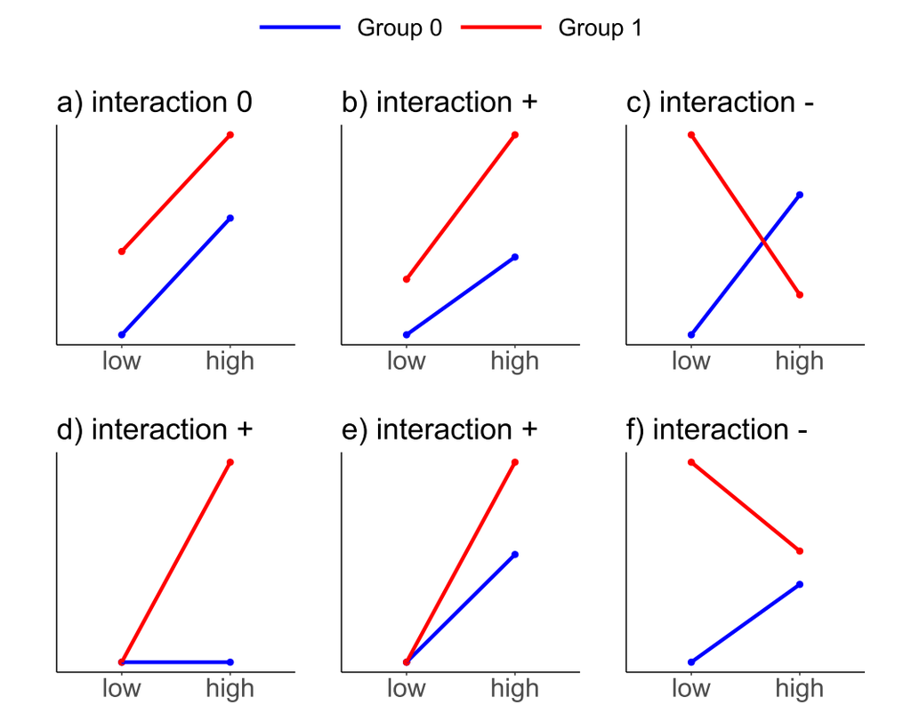

↑ 图源：https://www.nature.com/articles/s41598-023-47057-0

- **方差分析ANOVA**（以2 × 2 “高低组别 × 男女性别”两因素组间设计ANOVA为例）
  - **主效应（main effect）**
    - 代表“平均效应”，某个因素在其他因素不同条件下的边际平均效应
    - 例：高组和低组之间的总体差异（无论男性和女性，组别的平均效应）
  - **交互作用（interaction）**
    - 代表“效应差异”，某个因素在其他因素不同条件下存在不同的效应
    - 例：高低组间的差异在男性和女性群体之间也存在差异（差异的差异）
- **交互作用显著后的简单效应检验**
  - **简单效应（simple effect）**，也称“条件效应”（conditional effect）
    - 通常特指：简单主效应（simple main effect），也称“条件主效应”（conditional main effect）
    - 例：分别在男性或女性群体中，高低组间的差异（组别的简单主效应）
  - （拓展）三阶交互作用（A × B × C）中的复杂情况
    - 简单交互作用（simple interaction）：C不同条件下的A × B简单交互作用
    - 简单简单效应（simple-simple effect）：B和C不同组合条件下的A简单主效应
- **某个因素多个条件间（≥ 3）的两两对比**
  - 事后检验（post-hoc test）
    - 通常特指：**事后多重比较（post-hoc multiple comparison）**
    - 需要对*p*值做**“多重比较校正”（adjust *p*-values for multiple comparisons）**以降低假阳性概率（false discovery rate, FDR）

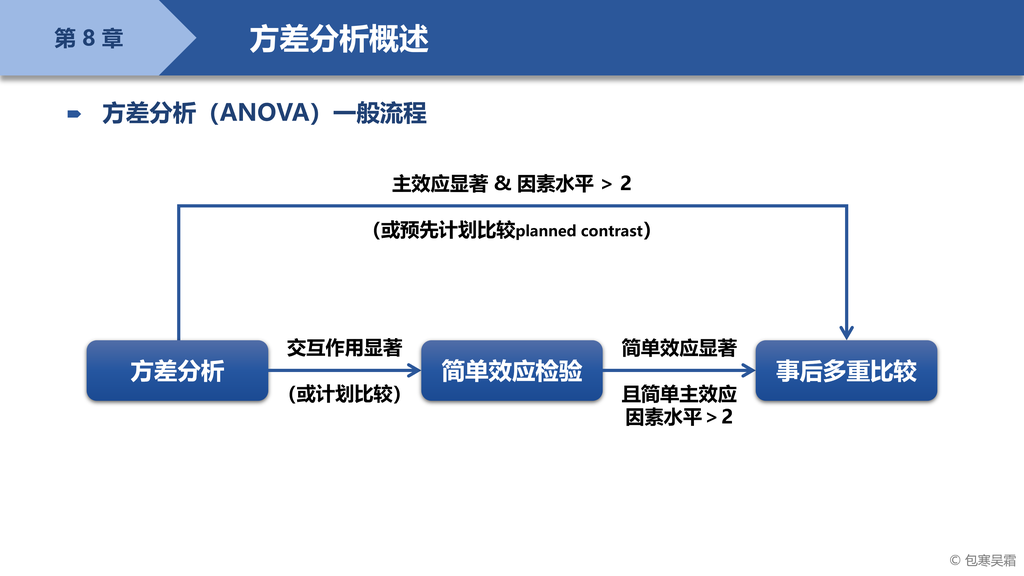

# 多因素方差分析

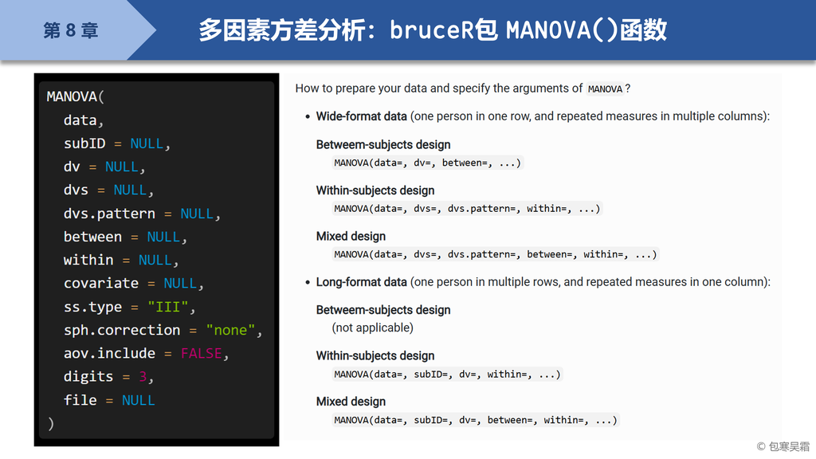

## 完全随机/组间设计ANOVA

#### 【实践1】组间设计ANOVA

- [`MANOVA()`函数帮助文档](https://psychbruce.github.io/bruceR/reference/MANOVA.html)

```r
between.1  # 单因素四水平组间设计
```

```
   A SCORE
1  1     3
2  1     6
3  1     4
4  1     3
5  1     5
6  1     7
7  1     5
8  1     2
9  2     4
10 2     6
11 2     4
12 2     2
13 2     4
14 2     5
```

[output cut: 18 more lines]

```r
MANOVA(between.1, dv="SCORE", between="A")
```

```
====== ANOVA (Between-Subjects Design) ======

Descriptives:
─────────────────────
 "A"   Mean    S.D. n
─────────────────────
  A1  4.375 (1.685) 8
  A2  3.875 (1.246) 8
  A3  7.000 (1.309) 8
  A4 10.000 (2.268) 8
─────────────────────
Total sample size: N = 32

ANOVA Table:
Dependent variable(s):      SCORE
Between-subjects factor(s): A
Within-subjects factor(s):  –
Covariate(s):               –
─────────────────────────────────────────────────────────────────
       MS   MSE df1 df2      F     p     η²p [90% CI of η²p]  η²G
─────────────────────────────────────────────────────────────────
A  63.375 2.812   3  28 22.533 <.001 ***   .707 [.526, .798] .707
─────────────────────────────────────────────────────────────────
MSE = mean square error (the residual variance of the linear model)
η²p = partial eta-squared = SS / (SS + SSE) = F * df1 / (F * df1 + df2)
ω²p = partial omega-squared = (F - 1) * df1 / (F * df1 + df2 + 1)
η²G = generalized eta-squared (see Olejnik & Algina, 2003)
Cohen’s f² = η²p / (1 - η²p)

Levene’s Test for Homogeneity of Variance:
───────────────────────────────────────
           Levene’s F df1 df2     p
───────────────────────────────────────
DV: SCORE       3.235   3  28  .037 *
───────────────────────────────────────
```

```r
between.2  # 2×3两因素组间设计
```

```
   A B SCORE
1  1 1     3
2  1 1     6
3  1 1     4
4  1 1     3
5  1 2     4
6  1 2     6
7  1 2     4
8  1 2     2
9  1 3     5
10 1 3     7
11 1 3     5
12 1 3     2
13 2 1     4
14 2 1     5
15 2 1     3
16 2 1     3
17 2 2     8
18 2 2     9
19 2 2     8
20 2 2     7
21 2 3    12
22 2 3    13
23 2 3    12
24 2 3    11
```

```r
MANOVA(between.2, dv="SCORE", between=c("A", "B"))
```

```
====== ANOVA (Between-Subjects Design) ======

Descriptives:
─────────────────────────
 "A" "B"   Mean    S.D. n
─────────────────────────
  A1  B1  4.000 (1.414) 4
  A1  B2  4.000 (1.633) 4
  A1  B3  4.750 (2.062) 4
  A2  B1  3.750 (0.957) 4
  A2  B2  8.000 (0.816) 4
  A2  B3 12.000 (0.816) 4
─────────────────────────
Total sample size: N = 24

ANOVA Table:
Dependent variable(s):      SCORE
Between-subjects factor(s): A, B
Within-subjects factor(s):  –
Covariate(s):               –
─────────────────────────────────────────────────────────────────────
           MS   MSE df1 df2      F     p     η²p [90% CI of η²p]  η²G
─────────────────────────────────────────────────────────────────────
A      80.667 1.861   1  18 43.343 <.001 ***   .707 [.482, .817] .707
B      40.542 1.861   2  18 21.784 <.001 ***   .708 [.470, .815] .708
A * B  28.292 1.861   2  18 15.201 <.001 ***   .628 [.347, .763] .628
─────────────────────────────────────────────────────────────────────
MSE = mean square error (the residual variance of the linear model)
η²p = partial eta-squared = SS / (SS + SSE) = F * df1 / (F * df1 + df2)
ω²p = partial omega-squared = (F - 1) * df1 / (F * df1 + df2 + 1)
η²G = generalized eta-squared (see Olejnik & Algina, 2003)
Cohen’s f² = η²p / (1 - η²p)

Levene’s Test for Homogeneity of Variance:
───────────────────────────────────────
           Levene’s F df1 df2     p
───────────────────────────────────────
DV: SCORE       0.605   5  18  .697
───────────────────────────────────────
```

```r
## 使用 emmeans 包的 emmip() 函数绘制交互图
## 请查阅帮助文档：?emmeans::emmip()
m = MANOVA(between.2, dv="SCORE", between=c("A", "B"))
```

```
====== ANOVA (Between-Subjects Design) ======

Descriptives:
─────────────────────────
 "A" "B"   Mean    S.D. n
─────────────────────────
  A1  B1  4.000 (1.414) 4
  A1  B2  4.000 (1.633) 4
  A1  B3  4.750 (2.062) 4
  A2  B1  3.750 (0.957) 4
  A2  B2  8.000 (0.816) 4
  A2  B3 12.000 (0.816) 4
─────────────────────────
Total sample size: N = 24

ANOVA Table:
Dependent variable(s):      SCORE
Between-subjects factor(s): A, B
Within-subjects factor(s):  –
Covariate(s):               –
─────────────────────────────────────────────────────────────────────
           MS   MSE df1 df2      F     p     η²p [90% CI of η²p]  η²G
─────────────────────────────────────────────────────────────────────
A      80.667 1.861   1  18 43.343 <.001 ***   .707 [.482, .817] .707
B      40.542 1.861   2  18 21.784 <.001 ***   .708 [.470, .815] .708
A * B  28.292 1.861   2  18 15.201 <.001 ***   .628 [.347, .763] .628
─────────────────────────────────────────────────────────────────────
MSE = mean square error (the residual variance of the linear model)
η²p = partial eta-squared = SS / (SS + SSE) = F * df1 / (F * df1 + df2)
ω²p = partial omega-squared = (F - 1) * df1 / (F * df1 + df2 + 1)
η²G = generalized eta-squared (see Olejnik & Algina, 2003)
Cohen’s f² = η²p / (1 - η²p)

Levene’s Test for Homogeneity of Variance:
───────────────────────────────────────
           Levene’s F df1 df2     p
───────────────────────────────────────
DV: SCORE       0.605   5  18  .697
───────────────────────────────────────
```

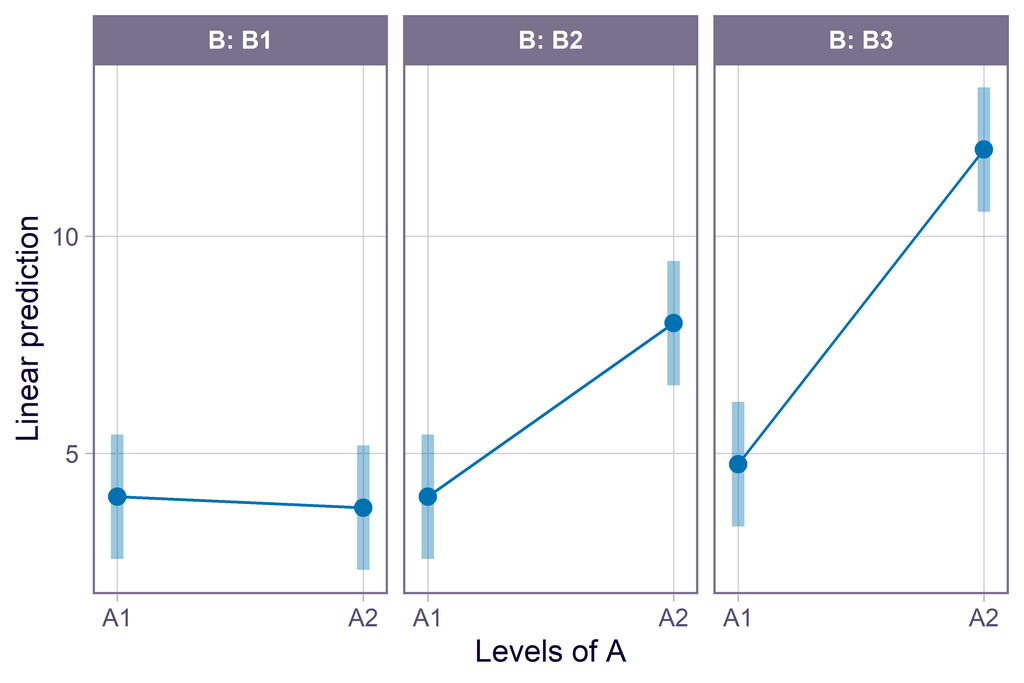

```r
emmip(m, ~ A | B, CIs=TRUE)
```

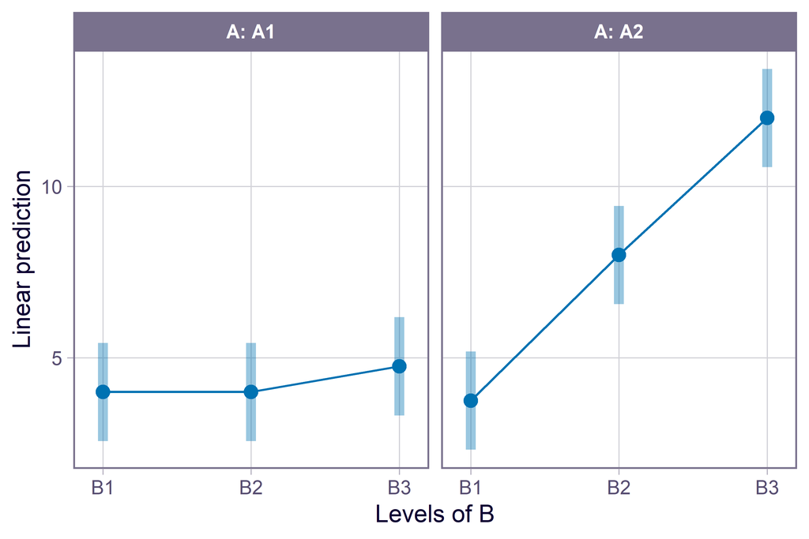

```r
emmip(m, ~ B | A, CIs=TRUE)
```

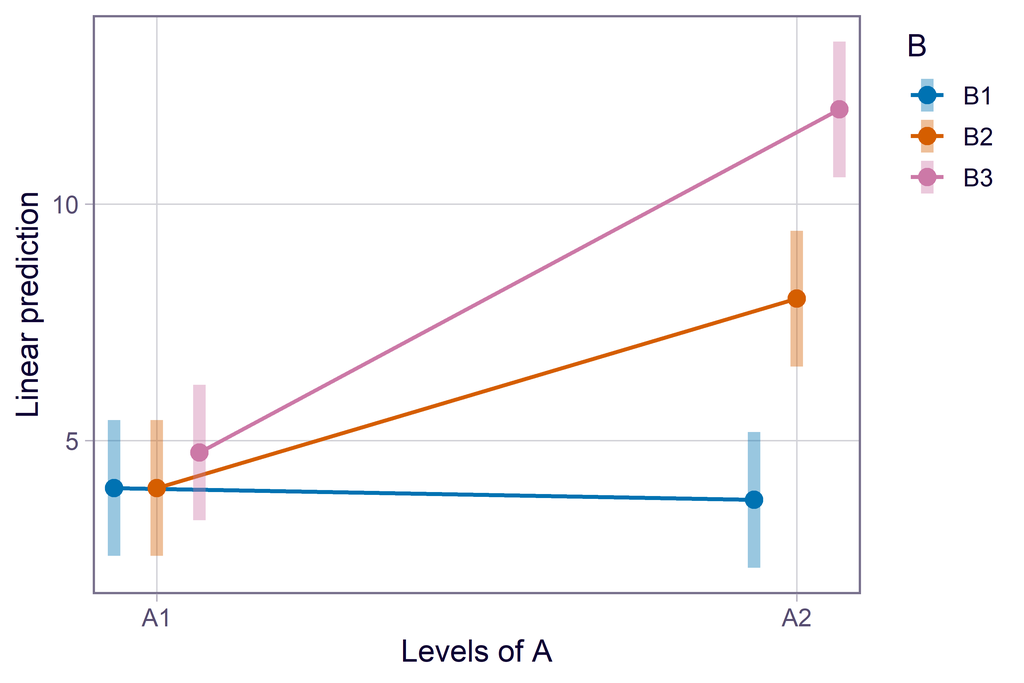

```r
emmip(m, B ~ A, CIs=TRUE)
```

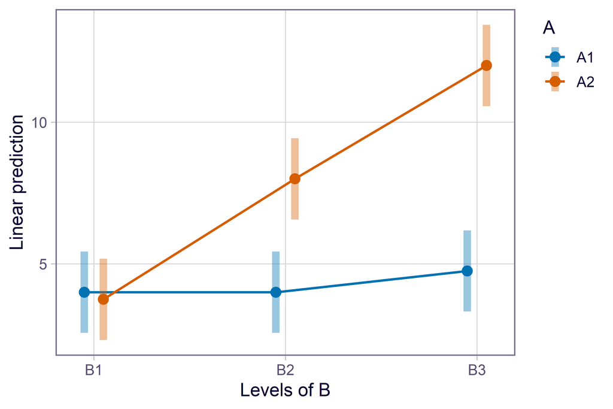

```r
emmip(m, A ~ B, CIs=TRUE)
```

```r
between.3  # 2×2×2三因素组间设计
```

```
   A B C SCORE
1  1 1 1     3
2  1 1 1     6
3  1 1 1     4
4  1 1 1     3
5  1 1 2     5
6  1 1 2     7
7  1 1 2     5
8  1 1 2     2
9  1 2 1     4
10 1 2 1     6
11 1 2 1     4
12 1 2 1     2
13 1 2 2     4
14 1 2 2     5
```

[output cut: 18 more lines]

```r
MANOVA(between.3, dv="SCORE", between=c("A", "B", "C"))
```

```
====== ANOVA (Between-Subjects Design) ======

Descriptives:
─────────────────────────────
 "A" "B" "C"   Mean    S.D. n
─────────────────────────────
  A1  B1  C1  4.000 (1.414) 4
  A1  B1  C2  4.750 (2.062) 4
  A1  B2  C1  4.000 (1.633) 4
  A1  B2  C2  3.750 (0.957) 4
  A2  B1  C1  8.000 (0.816) 4
  A2  B1  C2  6.000 (0.816) 4
  A2  B2  C1  8.000 (0.816) 4
  A2  B2  C2 12.000 (0.816) 4
─────────────────────────────
Total sample size: N = 32

ANOVA Table:
Dependent variable(s):      SCORE
Between-subjects factor(s): A, B, C
Within-subjects factor(s):  –
Covariate(s):               –
──────────────────────────────────────────────────────────────────────────
                MS   MSE df1 df2      F     p     η²p [90% CI of η²p]  η²G
──────────────────────────────────────────────────────────────────────────
A          153.125 1.563   1  24 98.000 <.001 ***   .803 [.670, .870] .803
B           12.500 1.563   1  24  8.000  .009 **    .250 [.042, .466] .250
C            3.125 1.563   1  24  2.000  .170       .077 [.000, .283] .077
A * B       24.500 1.563   1  24 15.680 <.001 ***   .395 [.147, .585] .395
A * C        1.125 1.563   1  24  0.720  .405       .029 [.000, .204] .029
B * C       12.500 1.563   1  24  8.000  .009 **    .250 [.042, .466] .250
A * B * C   24.500 1.563   1  24 15.680 <.001 ***   .395 [.147, .585] .395
──────────────────────────────────────────────────────────────────────────
MSE = mean square error (the residual variance of the linear model)
η²p = partial eta-squared = SS / (SS + SSE) = F * df1 / (F * df1 + df2)
ω²p = partial omega-squared = (F - 1) * df1 / (F * df1 + df2 + 1)
η²G = generalized eta-squared (see Olejnik & Algina, 2003)
Cohen’s f² = η²p / (1 - η²p)

Levene’s Test for Homogeneity of Variance:
───────────────────────────────────────
           Levene’s F df1 df2     p
───────────────────────────────────────
DV: SCORE       0.668   7  24  .697
───────────────────────────────────────
```

## 重复测量/组内设计ANOVA

#### 【实践2】组内设计ANOVA

- [`MANOVA()`函数帮助文档](https://psychbruce.github.io/bruceR/reference/MANOVA.html)

```r
within.1  # 单因素四水平组内设计
```

```
  ID A1 A2 A3 A4
1 S1  3  4  8  9
2 S2  6  6  9  8
3 S3  4  4  8  8
4 S4  3  2  7  7
5 S5  5  4  5 12
6 S6  7  5  6 13
7 S7  5  3  7 12
8 S8  2  3  6 11
```

```r
MANOVA(within.1,
       dvs = "A1:A4",
       dvs.pattern = "A(.)",
       within = "A")
```

```
Note:
dvs="A1:A4" is matched to variables:
A1, A2, A3, A4
```

```
====== ANOVA (Within-Subjects Design) ======

Descriptives:
─────────────────────
 "A"   Mean    S.D. n
─────────────────────
  A1  4.375 (1.685) 8
  A2  3.875 (1.246) 8
  A3  7.000 (1.309) 8
  A4 10.000 (2.268) 8
─────────────────────
Total sample size: N = 8

ANOVA Table:
Dependent variable(s):      A1, A2, A3, A4
Between-subjects factor(s): –
Within-subjects factor(s):  A
Covariate(s):               –
─────────────────────────────────────────────────────────────────
       MS   MSE df1 df2      F     p     η²p [90% CI of η²p]  η²G
─────────────────────────────────────────────────────────────────
A  63.375 2.518   3  21 25.170 <.001 ***   .782 [.609, .858] .707
─────────────────────────────────────────────────────────────────
MSE = mean square error (the residual variance of the linear model)
η²p = partial eta-squared = SS / (SS + SSE) = F * df1 / (F * df1 + df2)
ω²p = partial omega-squared = (F - 1) * df1 / (F * df1 + df2 + 1)
η²G = generalized eta-squared (see Olejnik & Algina, 2003)
Cohen’s f² = η²p / (1 - η²p)

Levene’s Test for Homogeneity of Variance:
No between-subjects factors. No need to do the Levene’s test.

Mauchly’s Test of Sphericity:
────────────────────────
   Mauchly's W     p
────────────────────────
A       0.1899  .095 .
────────────────────────
```

```r
# 相同：
MANOVA(within.1,
       dvs = c("A1", "A2", "A3", "A4"),
       dvs.pattern = "A(.)",
       within = "AnyVarNameIsOK")
```

```
====== ANOVA (Within-Subjects Design) ======

Descriptives:
──────────────────────────────────
 "AnyVarNameIsOK"   Mean    S.D. n
──────────────────────────────────
  AnyVarNameIsOK1  4.375 (1.685) 8
  AnyVarNameIsOK2  3.875 (1.246) 8
  AnyVarNameIsOK3  7.000 (1.309) 8
  AnyVarNameIsOK4 10.000 (2.268) 8
──────────────────────────────────
Total sample size: N = 8

ANOVA Table:
Dependent variable(s):      A1, A2, A3, A4
Between-subjects factor(s): –
Within-subjects factor(s):  AnyVarNameIsOK
Covariate(s):               –
──────────────────────────────────────────────────────────────────────────────
                    MS   MSE df1 df2      F     p     η²p [90% CI of η²p]  η²G
──────────────────────────────────────────────────────────────────────────────
AnyVarNameIsOK  63.375 2.518   3  21 25.170 <.001 ***   .782 [.609, .858] .707
──────────────────────────────────────────────────────────────────────────────
MSE = mean square error (the residual variance of the linear model)
η²p = partial eta-squared = SS / (SS + SSE) = F * df1 / (F * df1 + df2)
ω²p = partial omega-squared = (F - 1) * df1 / (F * df1 + df2 + 1)
η²G = generalized eta-squared (see Olejnik & Algina, 2003)
Cohen’s f² = η²p / (1 - η²p)

Levene’s Test for Homogeneity of Variance:
No between-subjects factors. No need to do the Levene’s test.

Mauchly’s Test of Sphericity:
─────────────────────────────────────
                Mauchly's W     p
─────────────────────────────────────
AnyVarNameIsOK       0.1899  .095 .
─────────────────────────────────────
```

```r
within.2  # 2×3两因素组内设计
```

```
  ID A1B1 A1B2 A1B3 A2B1 A2B2 A2B3
1 S1    3    4    5    4    8   12
2 S2    6    6    7    5    9   13
3 S3    4    4    5    3    8   12
4 S4    3    2    2    3    7   11
```

```r
m = MANOVA(within.2,
           dvs = "A1B1:A2B3",
           dvs.pattern = "A(.)B(.)",
           within = c("A", "B"))
```

```
Note:
dvs="A1B1:A2B3" is matched to variables:
A1B1, A1B2, A1B3, A2B1, A2B2, A2B3
```

```
====== ANOVA (Within-Subjects Design) ======

Descriptives:
─────────────────────────
 "A" "B"   Mean    S.D. n
─────────────────────────
  A1  B1  4.000 (1.414) 4
  A1  B2  4.000 (1.633) 4
  A1  B3  4.750 (2.062) 4
  A2  B1  3.750 (0.957) 4
  A2  B2  8.000 (0.816) 4
  A2  B3 12.000 (0.816) 4
─────────────────────────
Total sample size: N = 4

ANOVA Table:
Dependent variable(s):      A1B1, A1B2, A1B3, A2B1, A2B2, A2B3
Between-subjects factor(s): –
Within-subjects factor(s):  A, B
Covariate(s):               –
──────────────────────────────────────────────────────────────────────
           MS   MSE df1 df2       F     p     η²p [90% CI of η²p]  η²G
──────────────────────────────────────────────────────────────────────
A      80.667 1.111   1   3  72.600  .003 **    .960 [.699, .985] .707
B      40.542 0.264   2   6 153.632 <.001 ***   .981 [.930, .991] .708
A * B  28.292 0.236   2   6 119.824 <.001 ***   .976 [.911, .988] .628
──────────────────────────────────────────────────────────────────────
MSE = mean square error (the residual variance of the linear model)
η²p = partial eta-squared = SS / (SS + SSE) = F * df1 / (F * df1 + df2)
ω²p = partial omega-squared = (F - 1) * df1 / (F * df1 + df2 + 1)
η²G = generalized eta-squared (see Olejnik & Algina, 2003)
Cohen’s f² = η²p / (1 - η²p)

Levene’s Test for Homogeneity of Variance:
No between-subjects factors. No need to do the Levene’s test.

Mauchly’s Test of Sphericity:
────────────────────────────
       Mauchly's W     p
────────────────────────────
B           0.0665  .066 .
A * B       0.2491  .249
────────────────────────────
```

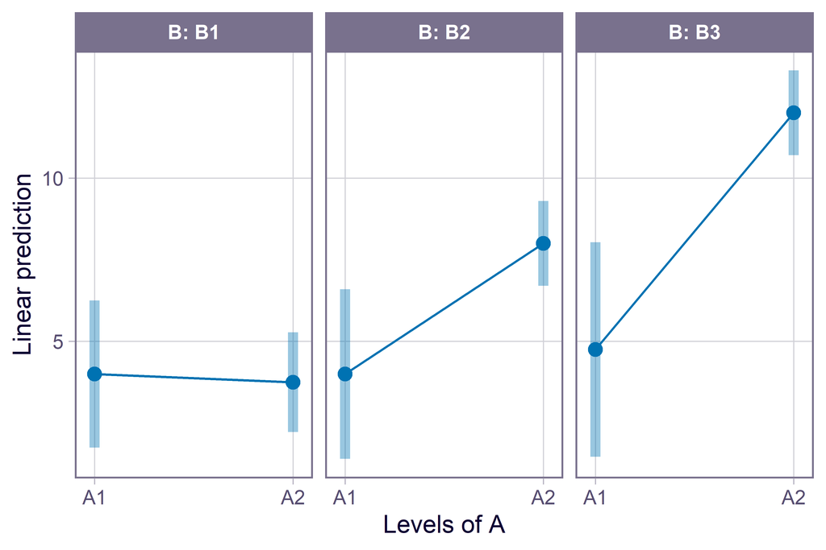

```r
emmip(m, ~ A | B, CIs=TRUE)
```

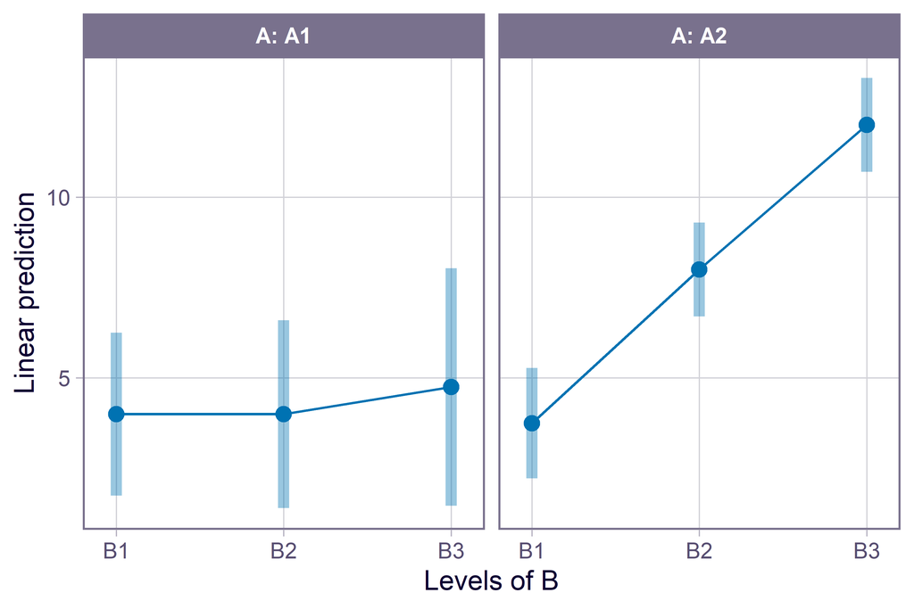

```r
emmip(m, ~ B | A, CIs=TRUE)
```

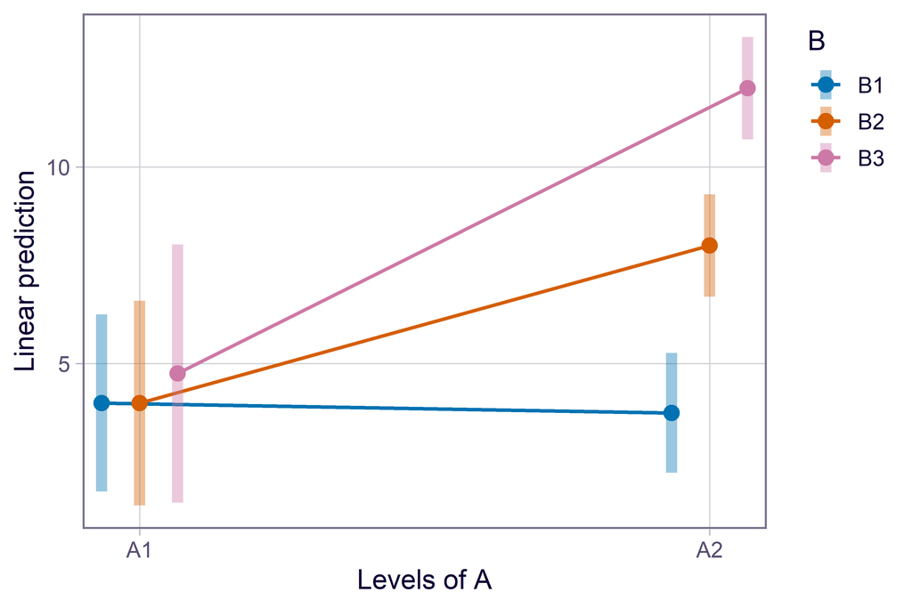

```r
emmip(m, B ~ A, CIs=TRUE)
```

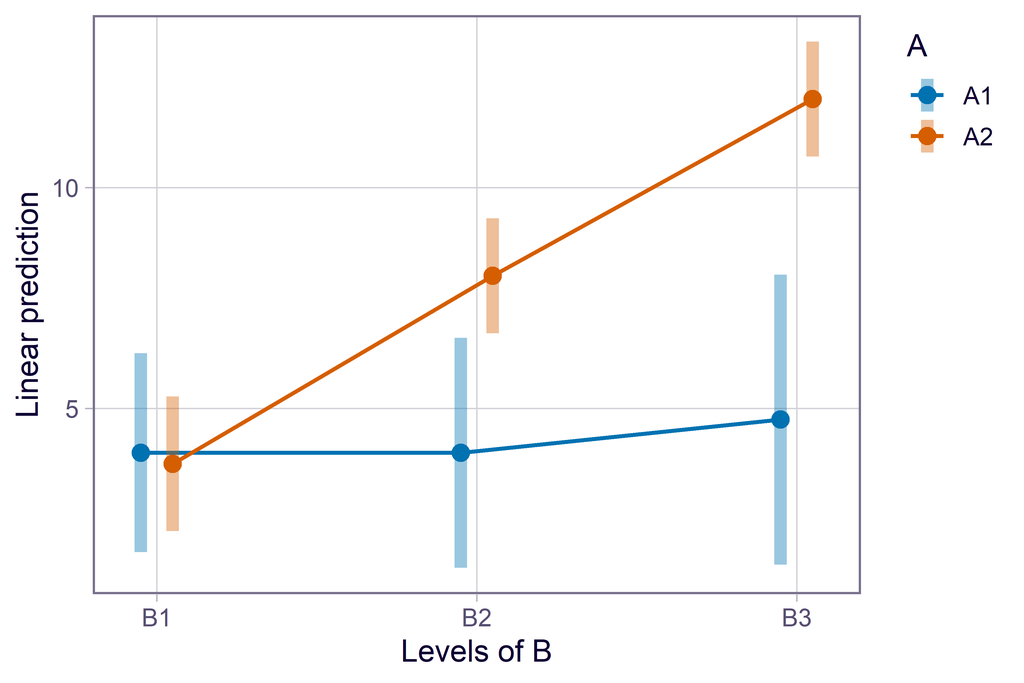

```r
emmip(m, A ~ B, CIs=TRUE)
```

```r
within.3  # 2×2×2三因素组内设计
```

```
  ID A1B1C1 A1B1C2 A1B2C1 A1B2C2 A2B1C1 A2B1C2 A2B2C1 A2B2C2
1 S1      3      5      4      4      8      5      9     12
2 S2      6      7      6      5      9      6      8     13
3 S3      4      5      4      3      8      7      8     12
4 S4      3      2      2      3      7      6      7     11
```

```r
MANOVA(within.3,
       dvs = "A1B1C1:A2B2C2",
       dvs.pattern = "A(.)B(.)C(.)",
       within = c("A", "B", "C"))
```

```
Note:
dvs="A1B1C1:A2B2C2" is matched to variables:
A1B1C1, A1B1C2, A1B2C1, A1B2C2, A2B1C1, A2B1C2, A2B2C1, A2B2C2
```

```
====== ANOVA (Within-Subjects Design) ======

Descriptives:
─────────────────────────────
 "A" "B" "C"   Mean    S.D. n
─────────────────────────────
  A1  B1  C1  4.000 (1.414) 4
  A1  B1  C2  4.750 (2.062) 4
  A1  B2  C1  4.000 (1.633) 4
  A1  B2  C2  3.750 (0.957) 4
  A2  B1  C1  8.000 (0.816) 4
  A2  B1  C2  6.000 (0.816) 4
  A2  B2  C1  8.000 (0.816) 4
  A2  B2  C2 12.000 (0.816) 4
─────────────────────────────
Total sample size: N = 4

ANOVA Table:
Dependent variable(s):      A1B1C1, A1B1C2, A1B2C1, A1B2C2, A2B1C1, A2B1C2, A2B2C1, A2B2C2
Between-subjects factor(s): –
Within-subjects factor(s):  A, B, C
Covariate(s):               –
──────────────────────────────────────────────────────────────────────────
                MS   MSE df1 df2      F     p     η²p [90% CI of η²p]  η²G
──────────────────────────────────────────────────────────────────────────
A          153.125 1.875   1   3 81.667  .003 **    .965 [.727, .986] .803
B           12.500 0.583   1   3 21.429  .019 *     .877 [.279, .953] .250
C            3.125 0.042   1   3 75.000  .003 **    .962 [.707, .985] .077
A * B       24.500 0.250   1   3 98.000  .002 **    .970 [.768, .989] .395
A * C        1.125 0.708   1   3  1.588  .297       .346 [.000, .749] .029
B * C       12.500 0.417   1   3 30.000  .012 *     .909 [.411, .965] .250
A * B * C   24.500 1.083   1   3 22.615  .018 *     .883 [.300, .956] .395
──────────────────────────────────────────────────────────────────────────
MSE = mean square error (the residual variance of the linear model)
η²p = partial eta-squared = SS / (SS + SSE) = F * df1 / (F * df1 + df2)
ω²p = partial omega-squared = (F - 1) * df1 / (F * df1 + df2 + 1)
η²G = generalized eta-squared (see Olejnik & Algina, 2003)
Cohen’s f² = η²p / (1 - η²p)

Levene’s Test for Homogeneity of Variance:
No between-subjects factors. No need to do the Levene’s test.

Mauchly’s Test of Sphericity:
The repeated measures have only two levels. The assumption of sphericity is always met.
```

## 混合设计ANOVA

#### 【实践3】混合设计ANOVA

- [`MANOVA()`函数帮助文档](https://psychbruce.github.io/bruceR/reference/MANOVA.html)

```r
mixed.2_1b1w  # 2×3两因素混合设计（A为组间，B为组内）
```

```
  A B1 B2 B3
1 1  3  4  5
2 1  6  6  7
3 1  4  4  5
4 1  3  2  2
5 2  4  8 12
6 2  5  9 13
7 2  3  8 12
8 2  3  7 11
```

```r
MANOVA(mixed.2_1b1w,
       dvs = "B1:B3",
       dvs.pattern = "B(.)",
       between = "A",
       within = "B")
```

```
Note:
dvs="B1:B3" is matched to variables:
B1, B2, B3
```

```
====== ANOVA (Mixed Design) ======

Descriptives:
─────────────────────────
 "A" "B"   Mean    S.D. n
─────────────────────────
  A1  B1  4.000 (1.414) 4
  A1  B2  4.000 (1.633) 4
  A1  B3  4.750 (2.062) 4
  A2  B1  3.750 (0.957) 4
  A2  B2  8.000 (0.816) 4
  A2  B3 12.000 (0.816) 4
─────────────────────────
Total sample size: N = 8

ANOVA Table:
Dependent variable(s):      B1, B2, B3
Between-subjects factor(s): A
Within-subjects factor(s):  B
Covariate(s):               –
──────────────────────────────────────────────────────────────────────
           MS   MSE df1 df2       F     p     η²p [90% CI of η²p]  η²G
──────────────────────────────────────────────────────────────────────
A      80.667 5.083   1   6  15.869  .007 **    .726 [.248, .871] .707
B      40.542 0.250   2  12 162.167 <.001 ***   .964 [.918, .980] .708
A * B  28.292 0.250   2  12 113.167 <.001 ***   .950 [.885, .971] .628
──────────────────────────────────────────────────────────────────────
MSE = mean square error (the residual variance of the linear model)
η²p = partial eta-squared = SS / (SS + SSE) = F * df1 / (F * df1 + df2)
ω²p = partial omega-squared = (F - 1) * df1 / (F * df1 + df2 + 1)
η²G = generalized eta-squared (see Olejnik & Algina, 2003)
Cohen’s f² = η²p / (1 - η²p)

Levene’s Test for Homogeneity of Variance:
────────────────────────────────────
        Levene’s F df1 df2     p
────────────────────────────────────
DV: B1       0.300   1   6  .604
DV: B2       0.600   1   6  .468
DV: B3       1.485   1   6  .269
────────────────────────────────────

Mauchly’s Test of Sphericity:
────────────────────────────
       Mauchly's W     p
────────────────────────────
B           0.1574  .010 **
A * B       0.1574  .010 **
────────────────────────────
The sphericity assumption is violated.
You may specify: sph.correction="GG" (or ="HF")
```

```r
MANOVA(mixed.2_1b1w,
       dvs = "B1:B3",
       dvs.pattern = "B(.)",
       between = "A",
       within = "B",
       sph.correction = "GG")
```

```
Note:
dvs="B1:B3" is matched to variables:
B1, B2, B3
```

```
====== ANOVA (Mixed Design) ======

Descriptives:
─────────────────────────
 "A" "B"   Mean    S.D. n
─────────────────────────
  A1  B1  4.000 (1.414) 4
  A1  B2  4.000 (1.633) 4
  A1  B3  4.750 (2.062) 4
  A2  B1  3.750 (0.957) 4
  A2  B2  8.000 (0.816) 4
  A2  B3 12.000 (0.816) 4
─────────────────────────
Total sample size: N = 8

ANOVA Table:
Dependent variable(s):      B1, B2, B3
Between-subjects factor(s): A
Within-subjects factor(s):  B
Covariate(s):               –
──────────────────────────────────────────────────────────────────────────
           MS   MSE   df1   df2       F     p     η²p [90% CI of η²p]  η²G
──────────────────────────────────────────────────────────────────────────
A      80.667 5.083 1.000 6.000  15.869  .007 **    .726 [.248, .871] .707
B      74.702 0.461 1.085 6.513 162.167 <.001 ***   .964 [.880, .983] .708
A * B  52.130 0.461 1.085 6.513 113.167 <.001 ***   .950 [.833, .976] .628
──────────────────────────────────────────────────────────────────────────
Sphericity correction method: GG (Greenhouse-Geisser)
MSE = mean square error (the residual variance of the linear model)
η²p = partial eta-squared = SS / (SS + SSE) = F * df1 / (F * df1 + df2)
ω²p = partial omega-squared = (F - 1) * df1 / (F * df1 + df2 + 1)
η²G = generalized eta-squared (see Olejnik & Algina, 2003)
Cohen’s f² = η²p / (1 - η²p)

Levene’s Test for Homogeneity of Variance:
────────────────────────────────────
        Levene’s F df1 df2     p
────────────────────────────────────
DV: B1       0.300   1   6  .604
DV: B2       0.600   1   6  .468
DV: B3       1.485   1   6  .269
────────────────────────────────────

Mauchly’s Test of Sphericity:
────────────────────────────
       Mauchly's W     p
────────────────────────────
B           0.1574  .010 **
A * B       0.1574  .010 **
────────────────────────────
```

```r
mixed.3_1b2w  # 2×2×2三因素混合设计（A为组间，B、C为组内）
```

```
  A B1C1 B1C2 B2C1 B2C2
1 1    3    5    4    4
2 1    6    7    6    5
3 1    4    5    4    3
4 1    3    2    2    3
5 2    8    5    9   12
6 2    9    6    8   13
7 2    8    7    8   12
8 2    7    6    7   11
```

```r
MANOVA(mixed.3_1b2w,
       dvs = "B1C1:B2C2",
       dvs.pattern = "B(.)C(.)",
       between = "A",
       within = c("B", "C"))
```

```
Note:
dvs="B1C1:B2C2" is matched to variables:
B1C1, B1C2, B2C1, B2C2
```

```
====== ANOVA (Mixed Design) ======

Descriptives:
─────────────────────────────
 "A" "B" "C"   Mean    S.D. n
─────────────────────────────
  A1  B1  C1  4.000 (1.414) 4
  A1  B1  C2  4.750 (2.062) 4
  A1  B2  C1  4.000 (1.633) 4
  A1  B2  C2  3.750 (0.957) 4
  A2  B1  C1  8.000 (0.816) 4
  A2  B1  C2  6.000 (0.816) 4
  A2  B2  C1  8.000 (0.816) 4
  A2  B2  C2 12.000 (0.816) 4
─────────────────────────────
Total sample size: N = 8

ANOVA Table:
Dependent variable(s):      B1C1, B1C2, B2C1, B2C2
Between-subjects factor(s): A
Within-subjects factor(s):  B, C
Covariate(s):               –
──────────────────────────────────────────────────────────────────────────
                MS   MSE df1 df2      F     p     η²p [90% CI of η²p]  η²G
──────────────────────────────────────────────────────────────────────────
A          153.125 4.708   1   6 32.522  .001 **    .844 [.503, .926] .803
B           12.500 0.417   1   6 30.000  .002 **    .833 [.474, .921] .250
A * B       24.500 0.417   1   6 58.800 <.001 ***   .907 [.684, .956] .395
C            3.125 0.375   1   6  8.333  .028 *     .581 [.064, .801] .077
A * C        1.125 0.375   1   6  3.000  .134       .333 [.000, .671] .029
B * C       12.500 0.750   1   6 16.667  .006 **    .735 [.264, .875] .250
A * B * C   24.500 0.750   1   6 32.667  .001 **    .845 [.505, .927] .395
──────────────────────────────────────────────────────────────────────────
MSE = mean square error (the residual variance of the linear model)
η²p = partial eta-squared = SS / (SS + SSE) = F * df1 / (F * df1 + df2)
ω²p = partial omega-squared = (F - 1) * df1 / (F * df1 + df2 + 1)
η²G = generalized eta-squared (see Olejnik & Algina, 2003)
Cohen’s f² = η²p / (1 - η²p)

Levene’s Test for Homogeneity of Variance:
──────────────────────────────────────
          Levene’s F df1 df2     p
──────────────────────────────────────
DV: B1C1       1.000   1   6  .356
DV: B1C2       1.485   1   6  .269
DV: B2C1       0.600   1   6  .468
DV: B2C2       0.500   1   6  .506
──────────────────────────────────────

Mauchly’s Test of Sphericity:
The repeated measures have only two levels. The assumption of sphericity is always met.
```

```r
mixed.3_2b1w  # 2×2×2三因素混合设计（A、C为组间，B为组内）
```

```
   A C B1 B2
1  1 1  3  4
2  1 1  6  6
3  1 1  4  4
4  1 1  3  2
5  1 2  5  4
6  1 2  7  5
7  1 2  5  3
8  1 2  2  3
9  2 1  8  9
10 2 1  9  8
11 2 1  8  8
12 2 1  7  7
13 2 2  5 12
14 2 2  6 13
15 2 2  7 12
16 2 2  6 11
```

```r
MANOVA(mixed.3_2b1w,
       dvs = "B1:B2",
       dvs.pattern = "B(.)",
       between = c("A", "C"),
       within = "B")
```

```
Note:
dvs="B1:B2" is matched to variables:
B1, B2
```

```
====== ANOVA (Mixed Design) ======

Descriptives:
─────────────────────────────
 "A" "C" "B"   Mean    S.D. n
─────────────────────────────
  A1  C1  B1  4.000 (1.414) 4
  A1  C1  B2  4.000 (1.633) 4
  A1  C2  B1  4.750 (2.062) 4
  A1  C2  B2  3.750 (0.957) 4
  A2  C1  B1  8.000 (0.816) 4
  A2  C1  B2  8.000 (0.816) 4
  A2  C2  B1  6.000 (0.816) 4
  A2  C2  B2 12.000 (0.816) 4
─────────────────────────────
Total sample size: N = 16

ANOVA Table:
Dependent variable(s):      B1, B2
Between-subjects factor(s): A, C
Within-subjects factor(s):  B
Covariate(s):               –
──────────────────────────────────────────────────────────────────────────
                MS   MSE df1 df2      F     p     η²p [90% CI of η²p]  η²G
──────────────────────────────────────────────────────────────────────────
A          153.125 2.542   1  12 60.246 <.001 ***   .834 [.639, .906] .803
C            3.125 2.542   1  12  1.230  .289       .093 [.000, .390] .077
A * C        1.125 2.542   1  12  0.443  .518       .036 [.000, .305] .029
B           12.500 0.583   1  12 21.429 <.001 ***   .641 [.308, .795] .250
A * B       24.500 0.583   1  12 42.000 <.001 ***   .778 [.532, .874] .395
C * B       12.500 0.583   1  12 21.429 <.001 ***   .641 [.308, .795] .250
A * C * B   24.500 0.583   1  12 42.000 <.001 ***   .778 [.532, .874] .395
──────────────────────────────────────────────────────────────────────────
MSE = mean square error (the residual variance of the linear model)
η²p = partial eta-squared = SS / (SS + SSE) = F * df1 / (F * df1 + df2)
ω²p = partial omega-squared = (F - 1) * df1 / (F * df1 + df2 + 1)
η²G = generalized eta-squared (see Olejnik & Algina, 2003)
Cohen’s f² = η²p / (1 - η²p)

Levene’s Test for Homogeneity of Variance:
────────────────────────────────────
        Levene’s F df1 df2     p
────────────────────────────────────
DV: B1       0.946   3  12  .449
DV: B2       0.423   3  12  .740
────────────────────────────────────

Mauchly’s Test of Sphericity:
The repeated measures have only two levels. The assumption of sphericity is always met.
```

# 简单效应检验与多重比较

## 多重比较

#### 【实践4】组间设计ANOVA的多重比较

- [`EMMEANS()`函数帮助文档](https://psychbruce.github.io/bruceR/reference/EMMEANS.html)（**E**stimated **M**arginal **Means**，估计边际均值）

```r
m = MANOVA(between.1, dv="SCORE", between="A")
```

```
====== ANOVA (Between-Subjects Design) ======

Descriptives:
─────────────────────
 "A"   Mean    S.D. n
─────────────────────
  A1  4.375 (1.685) 8
  A2  3.875 (1.246) 8
  A3  7.000 (1.309) 8
  A4 10.000 (2.268) 8
─────────────────────
Total sample size: N = 32

ANOVA Table:
Dependent variable(s):      SCORE
Between-subjects factor(s): A
Within-subjects factor(s):  –
Covariate(s):               –
─────────────────────────────────────────────────────────────────
       MS   MSE df1 df2      F     p     η²p [90% CI of η²p]  η²G
─────────────────────────────────────────────────────────────────
A  63.375 2.812   3  28 22.533 <.001 ***   .707 [.526, .798] .707
─────────────────────────────────────────────────────────────────
MSE = mean square error (the residual variance of the linear model)
η²p = partial eta-squared = SS / (SS + SSE) = F * df1 / (F * df1 + df2)
ω²p = partial omega-squared = (F - 1) * df1 / (F * df1 + df2 + 1)
η²G = generalized eta-squared (see Olejnik & Algina, 2003)
Cohen’s f² = η²p / (1 - η²p)

Levene’s Test for Homogeneity of Variance:
───────────────────────────────────────
           Levene’s F df1 df2     p
───────────────────────────────────────
DV: SCORE       3.235   3  28  .037 *
───────────────────────────────────────
```

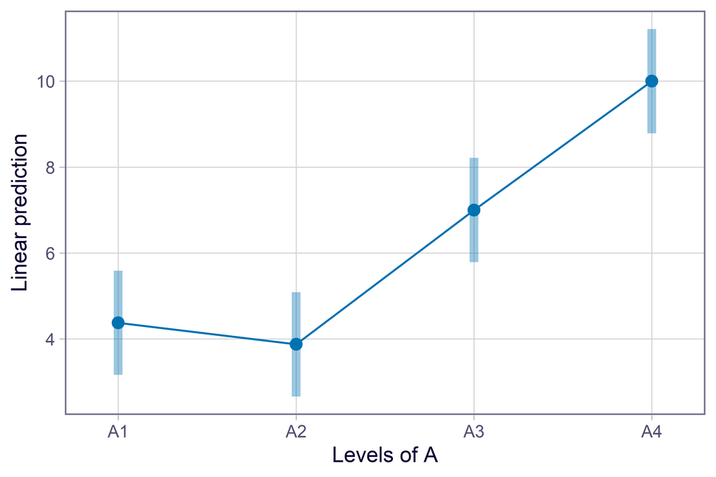

```r
emmip(m, ~ A, CIs=TRUE)
```

```r
EMMEANS(m, "A", p.adjust="none")
```

```
------ EMMEANS (effect = "A") ------

Joint Tests of "A":
────────────────────────────────────────────────────
 Effect df1 df2      F     p     η²p [90% CI of η²p]
────────────────────────────────────────────────────
      A   3  28 22.533 <.001 ***   .707 [.526, .798]
────────────────────────────────────────────────────
Note. Simple effects of repeated measures with 3 or more levels
are different from the results obtained with SPSS MANOVA syntax.

Univariate Tests of "A":
─────────────────────────────────────────────────────────
           Sum of Squares df Mean Square      F     p
─────────────────────────────────────────────────────────
Mean: "A"         190.125  3      63.375 22.533 <.001 ***
Residuals          78.750 28       2.812
─────────────────────────────────────────────────────────
Note. Identical to the results obtained with SPSS GLM EMMEANS syntax.

Estimated Marginal Means of "A":
───────────────────────────────────
 "A"  Mean [95% CI of Mean]    S.E.
───────────────────────────────────
  A1  4.375 [3.160,  5.590] (0.593)
  A2  3.875 [2.660,  5.090] (0.593)
  A3  7.000 [5.785,  8.215] (0.593)
  A4 10.000 [8.785, 11.215] (0.593)
───────────────────────────────────

Pairwise Comparisons of "A":
──────────────────────────────────────────────────────────────────────
 Contrast Estimate    S.E. df      t     p     Cohen’s d [95% CI of d]
──────────────────────────────────────────────────────────────────────
  A2 - A1   -0.500 (0.839) 28 -0.596  .556      -0.298 [-1.322, 0.726]
  A3 - A1    2.625 (0.839) 28  3.130  .004 **    1.565 [ 0.541, 2.589]
  A3 - A2    3.125 (0.839) 28  3.727 <.001 ***   1.863 [ 0.839, 2.888]
  A4 - A1    5.625 (0.839) 28  6.708 <.001 ***   3.354 [ 2.330, 4.378]
  A4 - A2    6.125 (0.839) 28  7.304 <.001 ***   3.652 [ 2.628, 4.676]
  A4 - A3    3.000 (0.839) 28  3.578  .001 **    1.789 [ 0.765, 2.813]
──────────────────────────────────────────────────────────────────────
Pooled SD for computing Cohen’s d: 1.677

Disclaimer:
By default, pooled SD is Root Mean Square Error (RMSE).
There is much disagreement on how to compute Cohen’s d.
You are completely responsible for setting `sd.pooled`.
You might also use `effectsize::t_to_d()` to compute d.
```

```r
EMMEANS(m, "A", p.adjust="bonferroni")
```

```
------ EMMEANS (effect = "A") ------

Joint Tests of "A":
────────────────────────────────────────────────────
 Effect df1 df2      F     p     η²p [90% CI of η²p]
────────────────────────────────────────────────────
      A   3  28 22.533 <.001 ***   .707 [.526, .798]
────────────────────────────────────────────────────
Note. Simple effects of repeated measures with 3 or more levels
are different from the results obtained with SPSS MANOVA syntax.

Univariate Tests of "A":
─────────────────────────────────────────────────────────
           Sum of Squares df Mean Square      F     p
─────────────────────────────────────────────────────────
Mean: "A"         190.125  3      63.375 22.533 <.001 ***
Residuals          78.750 28       2.812
─────────────────────────────────────────────────────────
Note. Identical to the results obtained with SPSS GLM EMMEANS syntax.

Estimated Marginal Means of "A":
───────────────────────────────────
 "A"  Mean [95% CI of Mean]    S.E.
───────────────────────────────────
  A1  4.375 [3.160,  5.590] (0.593)
  A2  3.875 [2.660,  5.090] (0.593)
  A3  7.000 [5.785,  8.215] (0.593)
  A4 10.000 [8.785, 11.215] (0.593)
───────────────────────────────────

Pairwise Comparisons of "A":
──────────────────────────────────────────────────────────────────────
 Contrast Estimate    S.E. df      t     p     Cohen’s d [95% CI of d]
──────────────────────────────────────────────────────────────────────
  A2 - A1   -0.500 (0.839) 28 -0.596 1.000      -0.298 [-1.718, 1.121]
  A3 - A1    2.625 (0.839) 28  3.130  .024 *     1.565 [ 0.146, 2.985]
  A3 - A2    3.125 (0.839) 28  3.727  .005 **    1.863 [ 0.444, 3.283]
  A4 - A1    5.625 (0.839) 28  6.708 <.001 ***   3.354 [ 1.935, 4.774]
  A4 - A2    6.125 (0.839) 28  7.304 <.001 ***   3.652 [ 2.233, 5.072]
  A4 - A3    3.000 (0.839) 28  3.578  .008 **    1.789 [ 0.369, 3.208]
──────────────────────────────────────────────────────────────────────
Pooled SD for computing Cohen’s d: 1.677
P-value adjustment: Bonferroni method for 6 tests.

Disclaimer:
By default, pooled SD is Root Mean Square Error (RMSE).
There is much disagreement on how to compute Cohen’s d.
You are completely responsible for setting `sd.pooled`.
You might also use `effectsize::t_to_d()` to compute d.
```

```r
EMMEANS(m, "A", contrast="seq")
```

```
------ EMMEANS (effect = "A") ------

Joint Tests of "A":
────────────────────────────────────────────────────
 Effect df1 df2      F     p     η²p [90% CI of η²p]
────────────────────────────────────────────────────
      A   3  28 22.533 <.001 ***   .707 [.526, .798]
────────────────────────────────────────────────────
Note. Simple effects of repeated measures with 3 or more levels
are different from the results obtained with SPSS MANOVA syntax.

Univariate Tests of "A":
─────────────────────────────────────────────────────────
           Sum of Squares df Mean Square      F     p
─────────────────────────────────────────────────────────
Mean: "A"         190.125  3      63.375 22.533 <.001 ***
Residuals          78.750 28       2.812
─────────────────────────────────────────────────────────
Note. Identical to the results obtained with SPSS GLM EMMEANS syntax.

Estimated Marginal Means of "A":
───────────────────────────────────
 "A"  Mean [95% CI of Mean]    S.E.
───────────────────────────────────
  A1  4.375 [3.160,  5.590] (0.593)
  A2  3.875 [2.660,  5.090] (0.593)
  A3  7.000 [5.785,  8.215] (0.593)
  A4 10.000 [8.785, 11.215] (0.593)
───────────────────────────────────

Consecutive (Sequential) Comparisons of "A":
──────────────────────────────────────────────────────────────────────
 Contrast Estimate    S.E. df      t     p     Cohen’s d [95% CI of d]
──────────────────────────────────────────────────────────────────────
  A2 - A1   -0.500 (0.839) 28 -0.596 1.000      -0.298 [-1.571, 0.975]
  A3 - A2    3.125 (0.839) 28  3.727  .003 **    1.863 [ 0.590, 3.137]
  A4 - A3    3.000 (0.839) 28  3.578  .004 **    1.789 [ 0.516, 3.062]
──────────────────────────────────────────────────────────────────────
Pooled SD for computing Cohen’s d: 1.677
P-value adjustment: Bonferroni method for 3 tests.

Disclaimer:
By default, pooled SD is Root Mean Square Error (RMSE).
There is much disagreement on how to compute Cohen’s d.
You are completely responsible for setting `sd.pooled`.
You might also use `effectsize::t_to_d()` to compute d.
```

```r
EMMEANS(m, "A", contrast="poly")
```

```
------ EMMEANS (effect = "A") ------

Joint Tests of "A":
────────────────────────────────────────────────────
 Effect df1 df2      F     p     η²p [90% CI of η²p]
────────────────────────────────────────────────────
      A   3  28 22.533 <.001 ***   .707 [.526, .798]
────────────────────────────────────────────────────
Note. Simple effects of repeated measures with 3 or more levels
are different from the results obtained with SPSS MANOVA syntax.

Univariate Tests of "A":
─────────────────────────────────────────────────────────
           Sum of Squares df Mean Square      F     p
─────────────────────────────────────────────────────────
Mean: "A"         190.125  3      63.375 22.533 <.001 ***
Residuals          78.750 28       2.812
─────────────────────────────────────────────────────────
Note. Identical to the results obtained with SPSS GLM EMMEANS syntax.

Estimated Marginal Means of "A":
───────────────────────────────────
 "A"  Mean [95% CI of Mean]    S.E.
───────────────────────────────────
  A1  4.375 [3.160,  5.590] (0.593)
  A2  3.875 [2.660,  5.090] (0.593)
  A3  7.000 [5.785,  8.215] (0.593)
  A4 10.000 [8.785, 11.215] (0.593)
───────────────────────────────────

Polynomial Contrasts of "A":
───────────────────────────────────────────────
  Contrast Estimate    S.E. df      t     p
───────────────────────────────────────────────
 linear      20.000 (2.652) 28  7.542 <.001 ***
 quadratic    3.500 (1.186) 28  2.951  .006 **
 cubic       -3.750 (2.652) 28 -1.414  .168
───────────────────────────────────────────────


Disclaimer:
By default, pooled SD is Root Mean Square Error (RMSE).
There is much disagreement on how to compute Cohen’s d.
You are completely responsible for setting `sd.pooled`.
You might also use `effectsize::t_to_d()` to compute d.
```

#### 【探索发现】多重比较的p值校正方法

`p.adjust`参数

- `"none"`（无校正）
- `"fdr"`
- `"hochberg"`
- `"hommel"`
- `"holm"`
- `"tukey"`
- `"mvt"`
- `"dunnettx"`
- `"sidak"`
- `"scheffe"`
- `"bonferroni"`（默认，最严格）
  - Bonferroni校正：直接将原始*p*值与多重比较次数*n*相乘，得到校正后的*p*值
    - 比如，3个条件之间的两两比较组合有C(3, 2) = 3次，某效应的原始*p* = .04，校正后*p* = .04 × 3 = .12，不再显著

## 简单效应检验

#### 【实践5】组间设计ANOVA的简单效应检验

- [`EMMEANS()`函数帮助文档](https://psychbruce.github.io/bruceR/reference/EMMEANS.html)（**E**stimated **M**arginal **Means**，估计边际均值）

```r
m = MANOVA(between.2, dv="SCORE", between=c("A", "B"))
```

```
====== ANOVA (Between-Subjects Design) ======

Descriptives:
─────────────────────────
 "A" "B"   Mean    S.D. n
─────────────────────────
  A1  B1  4.000 (1.414) 4
  A1  B2  4.000 (1.633) 4
  A1  B3  4.750 (2.062) 4
  A2  B1  3.750 (0.957) 4
  A2  B2  8.000 (0.816) 4
  A2  B3 12.000 (0.816) 4
─────────────────────────
Total sample size: N = 24

ANOVA Table:
Dependent variable(s):      SCORE
Between-subjects factor(s): A, B
Within-subjects factor(s):  –
Covariate(s):               –
─────────────────────────────────────────────────────────────────────
           MS   MSE df1 df2      F     p     η²p [90% CI of η²p]  η²G
─────────────────────────────────────────────────────────────────────
A      80.667 1.861   1  18 43.343 <.001 ***   .707 [.482, .817] .707
B      40.542 1.861   2  18 21.784 <.001 ***   .708 [.470, .815] .708
A * B  28.292 1.861   2  18 15.201 <.001 ***   .628 [.347, .763] .628
─────────────────────────────────────────────────────────────────────
MSE = mean square error (the residual variance of the linear model)
η²p = partial eta-squared = SS / (SS + SSE) = F * df1 / (F * df1 + df2)
ω²p = partial omega-squared = (F - 1) * df1 / (F * df1 + df2 + 1)
η²G = generalized eta-squared (see Olejnik & Algina, 2003)
Cohen’s f² = η²p / (1 - η²p)

Levene’s Test for Homogeneity of Variance:
───────────────────────────────────────
           Levene’s F df1 df2     p
───────────────────────────────────────
DV: SCORE       0.605   5  18  .697
───────────────────────────────────────
```

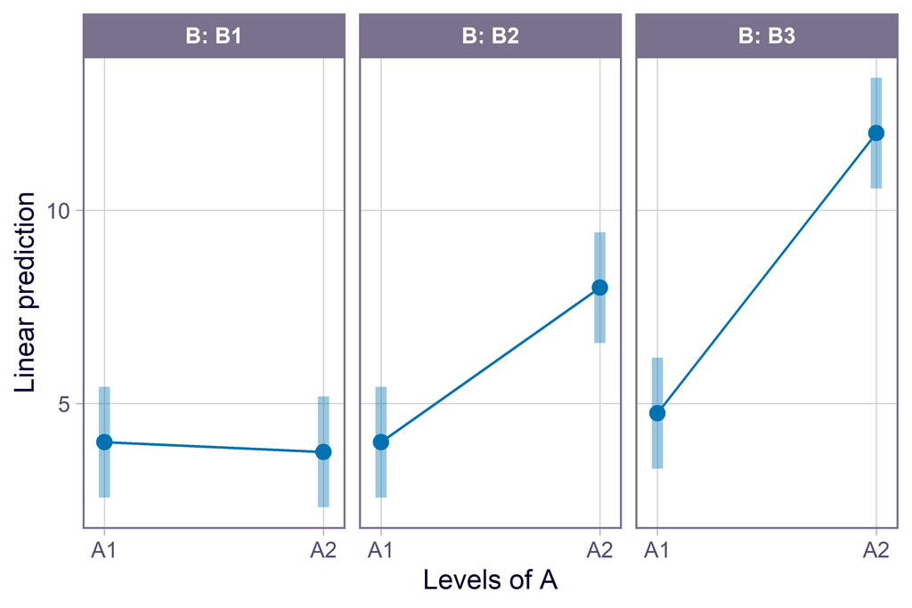

```r
emmip(m, ~ A | B, CIs=TRUE)
```

```r
EMMEANS(m, "A", by="B")
```

```
------ EMMEANS (effect = "A") ------

Joint Tests of "A":
────────────────────────────────────────────────────────
 Effect "B" df1 df2      F     p     η²p [90% CI of η²p]
────────────────────────────────────────────────────────
      A  B1   1  18  0.067  .798       .004 [.000, .137]
      A  B2   1  18 17.194 <.001 ***   .489 [.198, .674]
      A  B3   1  18 56.485 <.001 ***   .758 [.564, .849]
────────────────────────────────────────────────────────
Note. Simple effects of repeated measures with 3 or more levels
are different from the results obtained with SPSS MANOVA syntax.

Univariate Tests of "A":
─────────────────────────────────────────────────────────
           Sum of Squares df Mean Square      F     p
─────────────────────────────────────────────────────────
B1: "A"             0.125  1       0.125  0.067  .798
B2: "A"            32.000  1      32.000 17.194 <.001 ***
B3: "A"           105.125  1     105.125 56.485 <.001 ***
Residuals          33.500 18       1.861
─────────────────────────────────────────────────────────
Note. Identical to the results obtained with SPSS GLM EMMEANS syntax.

Estimated Marginal Means of "A":
────────────────────────────────────────
 "A" "B"   Mean [95% CI of Mean]    S.E.
────────────────────────────────────────
  A1  B1  4.000 [ 2.567,  5.433] (0.682)
  A2  B1  3.750 [ 2.317,  5.183] (0.682)
  A1  B2  4.000 [ 2.567,  5.433] (0.682)
  A2  B2  8.000 [ 6.567,  9.433] (0.682)
  A1  B3  4.750 [ 3.317,  6.183] (0.682)
  A2  B3 12.000 [10.567, 13.433] (0.682)
────────────────────────────────────────

Pairwise Comparisons of "A":
──────────────────────────────────────────────────────────────────────────
 Contrast "B" Estimate    S.E. df      t     p     Cohen’s d [95% CI of d]
──────────────────────────────────────────────────────────────────────────
  A2 - A1  B1   -0.250 (0.965) 18 -0.259  .798      -0.183 [-1.669, 1.302]
  A2 - A1  B2    4.000 (0.965) 18  4.147 <.001 ***   2.932 [ 1.446, 4.418]
  A2 - A1  B3    7.250 (0.965) 18  7.516 <.001 ***   5.314 [ 3.829, 6.800]
──────────────────────────────────────────────────────────────────────────
Pooled SD for computing Cohen’s d: 1.364
No need to adjust p values.

Disclaimer:
By default, pooled SD is Root Mean Square Error (RMSE).
There is much disagreement on how to compute Cohen’s d.
You are completely responsible for setting `sd.pooled`.
You might also use `effectsize::t_to_d()` to compute d.
```

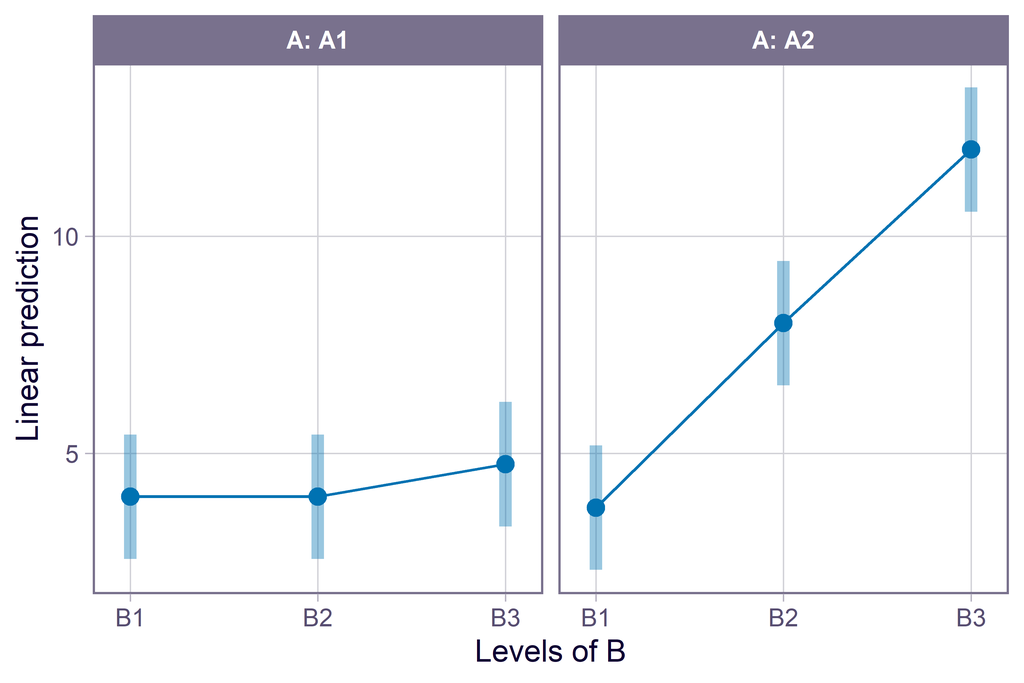

```r
emmip(m, ~ B | A, CIs=TRUE)
```

```r
EMMEANS(m, "B", by="A")
```

```
------ EMMEANS (effect = "B") ------

Joint Tests of "B":
────────────────────────────────────────────────────────
 Effect "A" df1 df2      F     p     η²p [90% CI of η²p]
────────────────────────────────────────────────────────
      B  A1   2  18  0.403  .674       .043 [.000, .205]
      B  A2   2  18 36.582 <.001 ***   .803 [.631, .876]
────────────────────────────────────────────────────────
Note. Simple effects of repeated measures with 3 or more levels
are different from the results obtained with SPSS MANOVA syntax.

Univariate Tests of "B":
─────────────────────────────────────────────────────────
           Sum of Squares df Mean Square      F     p
─────────────────────────────────────────────────────────
A1: "B"             1.500  2       0.750  0.403  .674
A2: "B"           136.167  2      68.083 36.582 <.001 ***
Residuals          33.500 18       1.861
─────────────────────────────────────────────────────────
Note. Identical to the results obtained with SPSS GLM EMMEANS syntax.

Estimated Marginal Means of "B":
────────────────────────────────────────
 "B" "A"   Mean [95% CI of Mean]    S.E.
────────────────────────────────────────
  B1  A1  4.000 [ 2.567,  5.433] (0.682)
  B2  A1  4.000 [ 2.567,  5.433] (0.682)
  B3  A1  4.750 [ 3.317,  6.183] (0.682)
  B1  A2  3.750 [ 2.317,  5.183] (0.682)
  B2  A2  8.000 [ 6.567,  9.433] (0.682)
  B3  A2 12.000 [10.567, 13.433] (0.682)
────────────────────────────────────────

Pairwise Comparisons of "B":
──────────────────────────────────────────────────────────────────────────
 Contrast "A" Estimate    S.E. df      t     p     Cohen’s d [95% CI of d]
──────────────────────────────────────────────────────────────────────────
  B2 - B1  A1   -0.000 (0.965) 18 -0.000 1.000      -0.000 [-1.866, 1.866]
  B3 - B1  A1    0.750 (0.965) 18  0.777 1.000       0.550 [-1.316, 2.416]
  B3 - B2  A1    0.750 (0.965) 18  0.777 1.000       0.550 [-1.316, 2.416]
  B2 - B1  A2    4.250 (0.965) 18  4.406  .001 **    3.115 [ 1.249, 4.981]
  B3 - B1  A2    8.250 (0.965) 18  8.552 <.001 ***   6.047 [ 4.181, 7.914]
  B3 - B2  A2    4.000 (0.965) 18  4.147  .002 **    2.932 [ 1.066, 4.798]
──────────────────────────────────────────────────────────────────────────
Pooled SD for computing Cohen’s d: 1.364
P-value adjustment: Bonferroni method for 3 tests.

Disclaimer:
By default, pooled SD is Root Mean Square Error (RMSE).
There is much disagreement on how to compute Cohen’s d.
You are completely responsible for setting `sd.pooled`.
You might also use `effectsize::t_to_d()` to compute d.
```

```r
## 使用管道操作符 %>% 连接多个 EMMEANS()
MANOVA(between.3, dv="SCORE", between=c("A", "B", "C")) %>%
  EMMEANS("A", by="B") %>%
  EMMEANS(c("A", "B"), by="C") %>%
  EMMEANS("A", by=c("B", "C"))
```

```
====== ANOVA (Between-Subjects Design) ======

Descriptives:
─────────────────────────────
 "A" "B" "C"   Mean    S.D. n
─────────────────────────────
  A1  B1  C1  4.000 (1.414) 4
  A1  B1  C2  4.750 (2.062) 4
  A1  B2  C1  4.000 (1.633) 4
  A1  B2  C2  3.750 (0.957) 4
  A2  B1  C1  8.000 (0.816) 4
  A2  B1  C2  6.000 (0.816) 4
  A2  B2  C1  8.000 (0.816) 4
  A2  B2  C2 12.000 (0.816) 4
─────────────────────────────
Total sample size: N = 32

ANOVA Table:
Dependent variable(s):      SCORE
Between-subjects factor(s): A, B, C
Within-subjects factor(s):  –
Covariate(s):               –
──────────────────────────────────────────────────────────────────────────
                MS   MSE df1 df2      F     p     η²p [90% CI of η²p]  η²G
──────────────────────────────────────────────────────────────────────────
A          153.125 1.563   1  24 98.000 <.001 ***   .803 [.670, .870] .803
B           12.500 1.563   1  24  8.000  .009 **    .250 [.042, .466] .250
C            3.125 1.563   1  24  2.000  .170       .077 [.000, .283] .077
A * B       24.500 1.563   1  24 15.680 <.001 ***   .395 [.147, .585] .395
A * C        1.125 1.563   1  24  0.720  .405       .029 [.000, .204] .029
B * C       12.500 1.563   1  24  8.000  .009 **    .250 [.042, .466] .250
A * B * C   24.500 1.563   1  24 15.680 <.001 ***   .395 [.147, .585] .395
──────────────────────────────────────────────────────────────────────────
MSE = mean square error (the residual variance of the linear model)
η²p = partial eta-squared = SS / (SS + SSE) = F * df1 / (F * df1 + df2)
ω²p = partial omega-squared = (F - 1) * df1 / (F * df1 + df2 + 1)
η²G = generalized eta-squared (see Olejnik & Algina, 2003)
Cohen’s f² = η²p / (1 - η²p)

Levene’s Test for Homogeneity of Variance:
```

[output cut: 167 more lines]

```
 Contrast "B" "C" Estimate    S.E. df     t     p     Cohen’s d [95% CI of d]
─────────────────────────────────────────────────────────────────────────────
  A2 - A1  B1  C1    4.000 (0.884) 24 4.525 <.001 ***   3.200 [ 1.741, 4.659]
  A2 - A1  B2  C1    4.000 (0.884) 24 4.525 <.001 ***   3.200 [ 1.741, 4.659]
  A2 - A1  B1  C2    1.250 (0.884) 24 1.414  .170       1.000 [-0.459, 2.459]
  A2 - A1  B2  C2    8.250 (0.884) 24 9.334 <.001 ***   6.600 [ 5.141, 8.059]
─────────────────────────────────────────────────────────────────────────────
Pooled SD for computing Cohen’s d: 1.250
No need to adjust p values.

Disclaimer:
By default, pooled SD is Root Mean Square Error (RMSE).
There is much disagreement on how to compute Cohen’s d.
You are completely responsible for setting `sd.pooled`.
You might also use `effectsize::t_to_d()` to compute d.
```

# * 拓展：特殊情况

#### 【探索发现】对于两因素方差分析（A × B），以下情况都有可能发生吗？

**交互作用 & 主效应：**

- 交互作用**显著**，A和B的主效应**都显著**（很正常）
- 交互作用**显著**，A和B的主效应**都不显著**（很正常，只有交互作用）
- 交互作用**不显著**，A和B的主效应**都显著**（很正常，只有主效应）
- 交互作用**不显著**，A和B的主效应**都不显著**（很正常，啥效应都没）

**交互作用 & 简单效应：**  
（例如：A在B1、B2水平上的两个简单主效应）

- 交互作用**显著**，A的两个简单效应**都显著**  
  （很正常，交互作用体现了简单效应的定量差异）
- 交互作用**显著**，A的两个简单效应**都不显著**❓️  
  （比较少见，但有概率发生！）
- 交互作用**显著**，A的简单效应一个**显著**、一个**不显著**  
  （很正常，交互作用体现了简单效应的定性差异）
- 交互作用**不显著**，A的两个简单效应**都显著**  
  （很正常，主效应为主）
- 交互作用**不显著**，A的两个简单效应**都不显著**  
  （很正常，啥效应都没）
- 交互作用**不显著**，A的简单效应一个**显著**、一个**不显著**❓️  
  （并不少见，显著的简单效应恰好卡在了临界点附近！）

> “Seeing is believing.”（眼见为实）

#### 【实践6】交互作用显著，但A的两个简单效应都不显著

```r
data1 = data.table(
  A = c(1, 1, 1, 1, 2, 2, 2, 2),
  B = c(1, 1, 2, 2, 1, 1, 2, 2),
  Y = c(0, 7, 10, 12, 12, 10, 7, 0)
)
m = MANOVA(data1, dv="Y", between=c("A", "B"))
```

```
====== ANOVA (Between-Subjects Design) ======

Descriptives:
─────────────────────────
 "A" "B"   Mean    S.D. n
─────────────────────────
  A1  B1  3.500 (4.950) 2
  A1  B2 11.000 (1.414) 2
  A2  B1 11.000 (1.414) 2
  A2  B2  3.500 (4.950) 2
─────────────────────────
Total sample size: N = 8

ANOVA Table:
Dependent variable(s):      Y
Between-subjects factor(s): A, B
Within-subjects factor(s):  –
Covariate(s):               –
──────────────────────────────────────────────────────────────────────
            MS    MSE df1 df2     F     p     η²p [90% CI of η²p]  η²G
──────────────────────────────────────────────────────────────────────
A        0.000 13.250   1   4 0.000 1.000       .000 [.000, .000] .000
B        0.000 13.250   1   4 0.000 1.000       .000 [.000, .000] .000
A * B  112.500 13.250   1   4 8.491  .044 *     .680 [.025, .867] .680
──────────────────────────────────────────────────────────────────────
MSE = mean square error (the residual variance of the linear model)
η²p = partial eta-squared = SS / (SS + SSE) = F * df1 / (F * df1 + df2)
ω²p = partial omega-squared = (F - 1) * df1 / (F * df1 + df2 + 1)
η²G = generalized eta-squared (see Olejnik & Algina, 2003)
Cohen’s f² = η²p / (1 - η²p)

Levene’s Test for Homogeneity of Variance:
```

```
─────────────────────────────────────────────────────────────
                                 Levene’s F df1 df2     p
─────────────────────────────────────────────────────────────
DV: Y  11361861823696222742664246882006.000   3   4 <.001 ***
─────────────────────────────────────────────────────────────
```

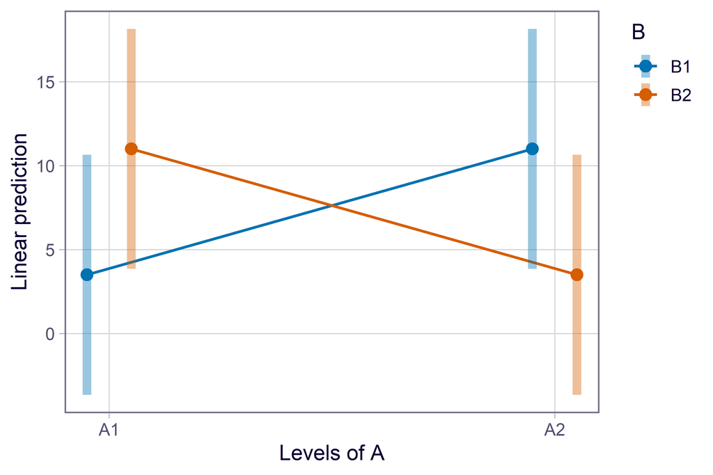

```r
emmip(m, B ~ A, CIs=TRUE)
```

```r
EMMEANS(m, "A", by="B")
```

```
------ EMMEANS (effect = "A") ------

Joint Tests of "A":
───────────────────────────────────────────────────────
 Effect "B" df1 df2     F     p     η²p [90% CI of η²p]
───────────────────────────────────────────────────────
      A  B1   1   4 4.245  .108       .515 [.000, .798]
      A  B2   1   4 4.245  .108       .515 [.000, .798]
───────────────────────────────────────────────────────
Note. Simple effects of repeated measures with 3 or more levels
are different from the results obtained with SPSS MANOVA syntax.

Univariate Tests of "A":
────────────────────────────────────────────────────────
           Sum of Squares df Mean Square     F     p
────────────────────────────────────────────────────────
B1: "A"            56.250  1      56.250 4.245  .108
B2: "A"            56.250  1      56.250 4.245  .108
Residuals          53.000  4      13.250
────────────────────────────────────────────────────────
Note. Identical to the results obtained with SPSS GLM EMMEANS syntax.

Estimated Marginal Means of "A":
────────────────────────────────────────
 "A" "B"   Mean [95% CI of Mean]    S.E.
────────────────────────────────────────
  A1  B1  3.500 [-3.646, 10.646] (2.574)
  A2  B1 11.000 [ 3.854, 18.146] (2.574)
  A1  B2 11.000 [ 3.854, 18.146] (2.574)
  A2  B2  3.500 [-3.646, 10.646] (2.574)
────────────────────────────────────────

Pairwise Comparisons of "A":
──────────────────────────────────────────────────────────────────────────
 Contrast "B" Estimate    S.E. df      t     p     Cohen’s d [95% CI of d]
──────────────────────────────────────────────────────────────────────────
  A2 - A1  B1    7.500 (3.640)  4  2.060  .108       2.060 [-0.716, 4.837]
  A2 - A1  B2   -7.500 (3.640)  4 -2.060  .108      -2.060 [-4.837, 0.716]
──────────────────────────────────────────────────────────────────────────
Pooled SD for computing Cohen’s d: 3.640
No need to adjust p values.

Disclaimer:
By default, pooled SD is Root Mean Square Error (RMSE).
There is much disagreement on how to compute Cohen’s d.
You are completely responsible for setting `sd.pooled`.
You might also use `effectsize::t_to_d()` to compute d.
```

[figure not shown]

#### 【实践7】交互作用不显著，但A的简单效应一个显著、一个不显著

```r
data2 = data.table(
  A = c(1, 1, 1, 1, 2, 2, 2, 2),
  B = c(1, 1, 2, 2, 1, 1, 2, 2),
  Y = c(0, 1, 0, 4, 5, 6, 2, 4)
)
m = MANOVA(data2, dv="Y", between=c("A", "B"))
```

```
====== ANOVA (Between-Subjects Design) ======

Descriptives:
────────────────────────
 "A" "B"  Mean    S.D. n
────────────────────────
  A1  B1 0.500 (0.707) 2
  A1  B2 2.000 (2.828) 2
  A2  B1 5.500 (0.707) 2
  A2  B2 3.000 (1.414) 2
────────────────────────
Total sample size: N = 8

ANOVA Table:
Dependent variable(s):      Y
Between-subjects factor(s): A, B
Within-subjects factor(s):  –
Covariate(s):               –
────────────────────────────────────────────────────────────────────
           MS   MSE df1 df2     F     p     η²p [90% CI of η²p]  η²G
────────────────────────────────────────────────────────────────────
A      18.000 2.750   1   4 6.545  .063 .     .621 [.000, .843] .621
B       0.500 2.750   1   4 0.182  .692       .043 [.000, .495] .043
A * B   8.000 2.750   1   4 2.909  .163       .421 [.000, .756] .421
────────────────────────────────────────────────────────────────────
MSE = mean square error (the residual variance of the linear model)
η²p = partial eta-squared = SS / (SS + SSE) = F * df1 / (F * df1 + df2)
ω²p = partial omega-squared = (F - 1) * df1 / (F * df1 + df2 + 1)
η²G = generalized eta-squared (see Olejnik & Algina, 2003)
Cohen’s f² = η²p / (1 - η²p)

Levene’s Test for Homogeneity of Variance:
```

```
─────────────────────────────────────────────────────────────
                                 Levene’s F df1 df2     p
─────────────────────────────────────────────────────────────
DV: Y  13645983859487056935286622800820.000   3   4 <.001 ***
─────────────────────────────────────────────────────────────
```

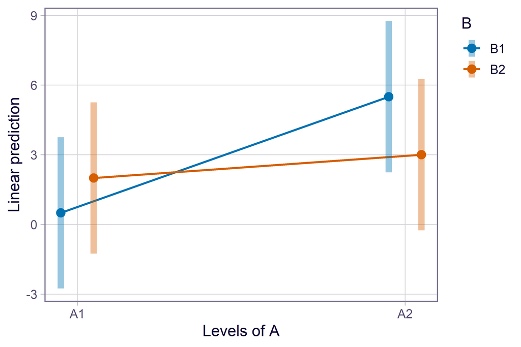

```r
emmip(m, B ~ A, CIs=TRUE)
```

```r
EMMEANS(m, "A", by="B")
```

```
------ EMMEANS (effect = "A") ------

Joint Tests of "A":
───────────────────────────────────────────────────────
 Effect "B" df1 df2     F     p     η²p [90% CI of η²p]
───────────────────────────────────────────────────────
      A  B1   1   4 9.091  .039 *     .694 [.043, .874]
      A  B2   1   4 0.364  .579       .083 [.000, .551]
───────────────────────────────────────────────────────
Note. Simple effects of repeated measures with 3 or more levels
are different from the results obtained with SPSS MANOVA syntax.

Univariate Tests of "A":
────────────────────────────────────────────────────────
           Sum of Squares df Mean Square     F     p
────────────────────────────────────────────────────────
B1: "A"            25.000  1      25.000 9.091  .039 *
B2: "A"             1.000  1       1.000 0.364  .579
Residuals          11.000  4       2.750
────────────────────────────────────────────────────────
Note. Identical to the results obtained with SPSS GLM EMMEANS syntax.

Estimated Marginal Means of "A":
──────────────────────────────────────
 "A" "B" Mean [95% CI of Mean]    S.E.
──────────────────────────────────────
  A1  B1 0.500 [-2.756, 3.756] (1.173)
  A2  B1 5.500 [ 2.244, 8.756] (1.173)
  A1  B2 2.000 [-1.256, 5.256] (1.173)
  A2  B2 3.000 [-0.256, 6.256] (1.173)
──────────────────────────────────────

Pairwise Comparisons of "A":
─────────────────────────────────────────────────────────────────────────
 Contrast "B" Estimate    S.E. df     t     p     Cohen’s d [95% CI of d]
─────────────────────────────────────────────────────────────────────────
  A2 - A1  B1    5.000 (1.658)  4 3.015  .039 *     3.015 [ 0.239, 5.792]
  A2 - A1  B2    1.000 (1.658)  4 0.603  .579       0.603 [-2.173, 3.379]
─────────────────────────────────────────────────────────────────────────
Pooled SD for computing Cohen’s d: 1.658
No need to adjust p values.

Disclaimer:
By default, pooled SD is Root Mean Square Error (RMSE).
There is much disagreement on how to compute Cohen’s d.
You are completely responsible for setting `sd.pooled`.
You might also use `effectsize::t_to_d()` to compute d.
```

# 【作业8】方差分析练习

作业要求：

- 基于[【作业4】](https://psychbruce.github.io/RCourse/Chap03#%E4%BD%9C%E4%B8%9A4%E6%9C%9F%E6%9C%AB%E8%87%AA%E9%80%89%E5%85%AC%E5%BC%80%E6%95%B0%E6%8D%AE%E5%AF%BC%E5%85%A5)和[【作业6】](https://psychbruce.github.io/RCourse/Chap05#%E4%BD%9C%E4%B8%9A6%E6%9C%9F%E6%9C%AB%E4%BD%9C%E4%B8%9A%E6%95%B0%E6%8D%AE%E5%8F%98%E9%87%8F%E8%AE%A1%E7%AE%97)的期末自选数据和代码积累，运用本章所学的方差分析方法和代码，练习**方差分析**（根据自己的数据情况选择最合适的一种方差分析类型）
- 使用R Markdown完成，对关键代码及结果要有注释说明

平台提交：

- 运行得到HTML网页文件的**关键部分截图（只需上传截图）**

[返回课程主页](https://psychbruce.github.io/RCourse/)

© 包寒吴霜